# The Relationship Between CO2 Emissions and Population Growth

Emmily Mandell, Isabella Jiang, Amber Kirkpatrick

## Introduction

As global climate change accelerates, identifying the macroeconomic drivers of carbon emissions is necessary for policy creation. Population growth is frequently cited as a primary driver due to scaling energy and industrial demands. This project evaluates a fundamental question: Is annual country-level population change a statistically significant predictor of changes in annual $CO_2$ emissions?

## Data Background & Preprocessing

This analysis integrates two primary open-source datasets spanning 1961 to 2023:

1. Global Population Data: Sourced from the World Bank, providing annual census derived total populations per country. [^1]
2. Annual $CO_2$ Emissions: Sourced from Our World in Data (Global Carbon Budget) measuring annual industrial and fossil fuel $CO_2$ output per country in tons. [^2]

### Data Pipeline and Feature Engineering

To create our data set we joined the population dataset and the carbon emissions dataset by country within the span that there is full data for both sets, which was 1961 to 2023. The resulting dataset had four variables, country name, year, annual CO2 emissions, and population, and was in tidy format with one row for each country and year combination.

To evaluate true year-over-year adjustments rather than simple absolute growth trends, we calculate the absolute first differences ($\Delta$) for both metrics, grouped strictly by country to prevent cross-border data contamination.

```r
#load raw data
co2_emission = read_csv("data/annual-co2-emissions-per-country.csv")
population = read_csv("data/global_population.csv")

#clean and reshape population data
population_long = population %>%
  pivot_longer(cols = matches("^(19|20)\\d{2}$"),
               names_to = "Year",
               values_to = "Population") %>%
  mutate(Year = as.integer(Year)) %>%
  select(`Country Name`, Year, Population)

#clean CO2 data
co2_clean = co2_emission %>%
  filter(Year >= 1960) %>%
  rename(`Country Name` = Entity, `CO2_Emissions` = `Annual CO₂ emissions`) %>%
  mutate(Year = as.integer((Year))) %>%
  select(`Country Name`, Year, CO2_Emissions)

#join data and engineer first difference features
df_cleaned = inner_join(population_long, co2_clean, by = c("Country Name", "Year")) %>%
  arrange(`Country Name`, Year) %>%
  group_by(`Country Name`) %>%
  mutate(population_change = Population - lag(Population),
         co2_change = CO2_Emissions - lag(CO2_Emissions)) %>%
  ungroup() %>%
  filter(!is.na(population_change) & !is.na(co2_change))

#summary statistics
total_countries = n_distinct(df_cleaned$`Country Name`)
total_obs = nrow(df_cleaned)
```

## Exploratory Data Analysis (EDA)

Understanding the connection between population growth and carbon dioxide emissions involves contextual knowledge and causality. Population growth affects human activities, which may result in greater energy consumption that in turn leads to increased carbon dioxide emissions.

### Macro Trends: Global Population vs. Total Emissions

Before evaluating annual differentials, we aggregated the data globally to assess macro level trajectories in population and $CO_2$ emissions. The graph below displays the global trends in population and $CO_2$ emissions by year.

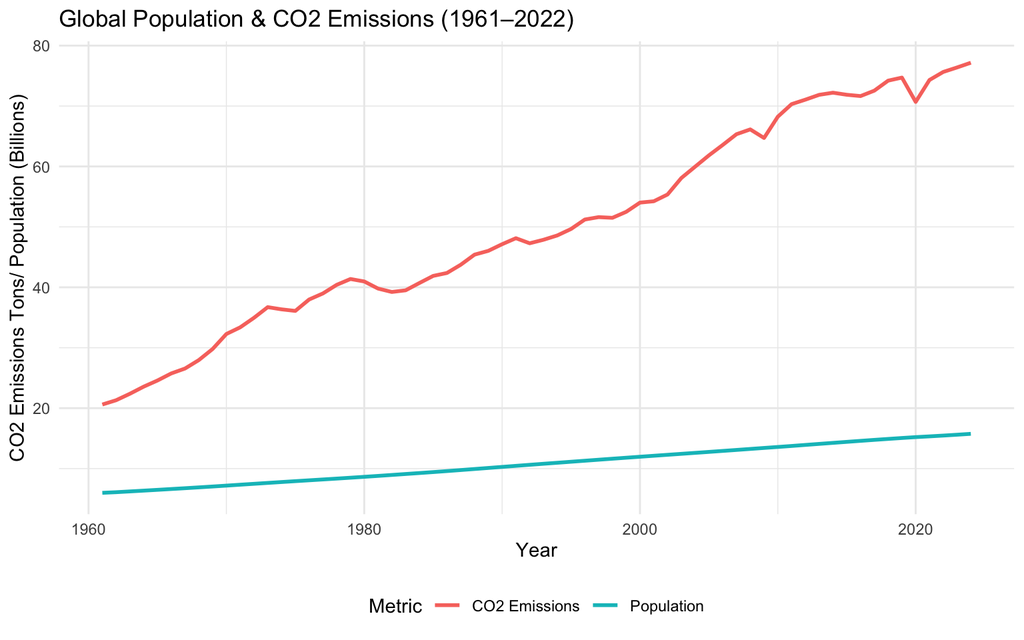

```r
#aggregate global data
global_trends = df_cleaned %>%
  group_by(Year) %>%
  summarize(Total_CO2_Billion_Tons = sum(CO2_Emissions, na.rm = TRUE) / 1e9,
            Total_Pop_Billion = sum(Population, na.rm = TRUE) / 1e9)

#plot global trends
ggplot(global_trends, aes(x = Year)) +
  geom_line(aes(y = Total_CO2_Billion_Tons, color = "CO2 Emissions"), size = 1) +
  geom_line(aes(y = Total_Pop_Billion, color = "Population"), size = 1) +
  labs(title = "Global Population & CO2 Emissions (1961–2022)",
       y = "CO2 Emissions Tons/ Population (Billions)",
       x = "Year",
       color = "Metric") +
  theme_minimal() +
  theme(legend.position = "bottom")
```

## Statistical Modeling

We will analyze the data using a linear regression model to determine the strength of this relationship to gain greater insight into the impact of population growth on the environment.

### Visualizing the Relationship

To handle extreme variances among nations, we look at changes greater than zero using a logarithmic transformation to linearize the visualization. The plot below illustrates the relationship between population changes and $CO_2$ emissions changes, with linear regression line to indicate the trend.

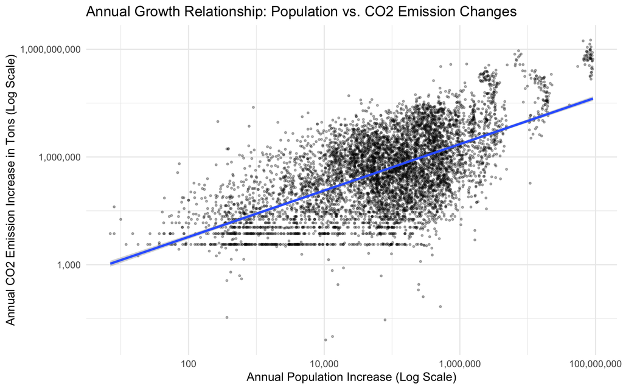

```r
# filter for positive growth values to prevent log-transformation errors in visualization
df_positive_growth = df_cleaned %>%
  filter(population_change > 0 & co2_change > 0)

#plot
ggplot(df_positive_growth, aes(x = population_change, y = co2_change)) +
  geom_point(alpha = 0.3, size = 0.6) +
  geom_smooth(method = "lm", se = TRUE) +
  scale_x_log10(labels = label_comma()) +
  scale_y_log10(labels = label_comma()) +
  labs(title = "Annual Growth Relationship: Population vs. CO2 Emission Changes",
       x = "Annual Population Increase (Log Scale)",
       y = "Annual CO2 Emission Increase in Tons (Log Scale)") +
  theme_minimal()
```

### Regression Analysis

Because the visualization maps a log-log scaling relationship, a true structural analysis requires a model matching that transformation strategy. We fit a Ordinary Least Squares (OLS) linear model predicting $\log_{10}(\Delta CO_2)$ based on $\log_{10}(\Delta Population)$.

```r
#linear regression model
fit_log = lm(log10(co2_change) ~ log10(population_change), data = df_positive_growth)
model_summary = glance(fit_log)
model_coeffs = tidy(fit_log)
summary(fit_log)
```

```
##
## Call:
## lm(formula = log10(co2_change) ~ log10(population_change), data = df_positive_growth)
##
## Residuals:
##     Min      1Q  Median      3Q     Max
## -4.3402 -0.6163  0.0360  0.6534  2.9909
##
## Coefficients:
##                          Estimate Std. Error t value Pr(>|t|)
## (Intercept)               2.48110    0.04990   49.72   <2e-16 ***
## log10(population_change)  0.64614    0.01003   64.42   <2e-16 ***
## ---
## Signif. codes:  0 '***' 0.001 '**' 0.01 '*' 0.05 '.' 0.1 ' ' 1
##
## Residual standard error: 0.8803 on 6686 degrees of freedom
## Multiple R-squared:  0.383,  Adjusted R-squared:  0.3829
## F-statistic:  4150 on 1 and 6686 DF,  p-value: < 2.2e-16
```

### Model Interpretation

Elasticity Coefficient ($\beta_1$): The model estimates a coefficient of 0.646. Because this is a log-log model evaluated on first differences, this that a 1% increase in the magnitude of annual population growth corresponds to an approximate 0.646% increase in the magnitude of annual $CO_2$ emission growth.

Significance: With t-statistic of 64.42 and a p-value of $< 2.2 \times 10^{-16}$, the relationship is highly statistically significant. This soundly rejects the hull hypothesis ($H_0: \beta_1 = 0$), providing empirical support for our alternative hypothesis that population growth shifts positively scale carbon emission changes.

## Discussion

### Future Research Frameworks

To iterate on this baseline study, future work should expand in the following directions:

- Multivariate Confounder Control: Integrating World Bank GDP metrics and global vehicle/transit registration statistics to decouple pure population growth from expanding consumer affluence.
- Heterogeneity Analysis: Evaluating whether this correlation is globally uniform, or if it breaks down when subsetting the data by economic status (e.g., OECD vs. developing economies).
- Epidemiological Impacts: Crossing these macro environmental insights with global health data to evaluate if regional surges in demographic carbon emissions correlate with measurable changes in population respiratory health metrics.

## References

[^1]: https://data.worldbank.org/indicator/SP.POP.TOTL
[^2]: https://ourworldindata.org/grapher/annual-co2-emissions-per-country